# pyLBM slides

[figure not shown]

Loïc Gouarin, Benjamin Graille

Laboratoire de mathématiques d'Orsay

3 juin 2015

## Les logiciels autour de LBM

### Palabos

- écrit en C++
- schémas disponibles:

  $D_2Q_9$, $D_3Q_{13}$, $D_3Q_{15}$, $D_3Q_{19}$ et $D_3Q_{27}$
- **BGK**, **MRT**, **modèle entropique**, ...
- différentes conditions aux limites:

  **Zou/He**, **Inamuro**, **bounce-back**, **périodique**, ...
- parallélisé avec **MPI**

### OpenLB

- écrit en C++
- schémas disponibles:

  $D_2Q_9$, $D_3Q_{13}$, $D_3Q_{15}$, $D_3Q_{19}$ et $D_3Q_{27}$
- **BGK**, **MRT**, **modèle entropique**, ...
- différentes conditions aux limites:

  **Zou/He**, **Inamuro**, **Bouzidi**, ...
- parallélisé avec **MPI** et **openMP**

### Sailfish

- écrit en Python
- schémas disponibles:

  $D_2Q_9$, $D_3Q_{13}$, $D_3Q_{15}$, $D_3Q_{19}$ et $D_3Q_{27}$
- **BGK**, **MRT**, **modèle entropique**, ...
- différentes conditions aux limites:

  **Zou/He**, **bounce-back**, ...
- parallélisé avec **CUDA** ou **OpenCL**

#### Avantages

- beaucoup de choix
- codes massivement parallèles
- codes de production

#### Inconvénients

- C++ n'est pas forcément facile d'accès
- assez rigide

## Les caractéristiques de PyLBM

- code écrit en Python
- code de recherche (et de production)
- pas de schémas prédéfinis (classique + vectoriel)
- flexible
- génération de codes optimisés
- parallélisation en utilisant MPI

### Idée générale

On écrit le schéma que l'on souhaite utiliser sous le formalisme de d'Humières.

$$ f(\mathbf{r}_i+e_\alpha \delta t, t + \delta t) - f(\mathbf{r}_i, t) = -M^{-1}\hat{S}\left[m(\mathbf{r}_i, t) - m^{eq}(\mathbf{r}_i, t)\right] $$

### Informations à fournir

- les vitesses,
- les moments conservés,
- les polynômes qui permettent d’écrire le changement de base qui diagonalise l’opérateur de relaxation,
- les équilibres,
- la diagonale de la matrice de collision $\hat{S}$.

### Exemple

On souhaite résoudre une équation d'advection sur un tore à l'aide d'un $D_1Q_2$

$$ \left\{ \begin{array}{l} \partial_t u + c \partial_x u = 0 \;, t > 0,\; 0 < x < 1,\; c=1/4, \\ u(t=0,x) = u_0(x), \\ u(t,x=0) = u(t,x=1) \end{array} \right. $$

### Initialisation

```python
import matplotlib.pyplot as plt
import numpy as np
import sympy as sp
import pyLBM

X, LA, u = sp.symbols('X,LA,u')

def u0(x):
    return np.exp(-.5*(x%1-.5)**2/0.05**2)

la = 1.
Tf = 4.
c = .25
s = 1.99
```

### Ecriture du schéma et du domaine de calcul

```python
D1Q2 = {
    'box': {'x': [0., 1.], 'label': -1},
    'space_step': 1./128,
    'scheme_velocity': la,
    'schemes':[
        {
            'velocities': [1, 2],
            'conserved_moments': u,
            'polynomials': [1, X],
            'relaxation_parameters': [0., s],
            'equilibrium': [u, c*u],
            'init': {u:(u0,)},
        },
    ],
}
```

### Simulation et représentation graphique

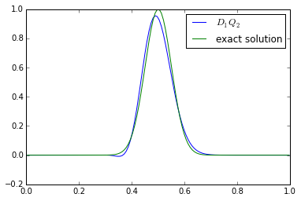

```python
sol = pyLBM.Simulation(D1Q2) # build the simulation
while sol.t < Tf:            # time loop
    sol.one_time_step()      # increment the solution of one time step

sol.f2m()
x = sol.domain.x[0][1:-1]
plt.plot(x, sol.m[0][0][1:-1], x, u0(x-c*sol.t))
plt.legend(["$D_1Q_2$", "exact solution"])
plt.show()
```

### Les briques de base dans pyLBM

- les vitesses et stencils,
- la géométrie,
- le domaine,
- le schéma,
- les conditions de bords.

### Les vitesses

- une vitesse est représentée par
  - une dimension
  - un numéro
  - ses coordonnées
- la numérotation des vitesses suit la convention pour le 1D et 2D.

```python
from pyLBM.stencil import Velocity

Velocity(dim=1, num=2)
```

```
(2: -1)
```

```python
Velocity(dim=2, num=5)
```

```
(5: 1, 1)
```

```python
Velocity(vx=1, vy=1)
```

```
(5: 1, 1)
```

```python
v = Velocity(vx=1, vy=1)
v.get_symmetric()
```

```
(7: -1, -1)
```

```python
v.get_symmetric(axis=0)
```

```
(8: 1, -1)
```

### Les stencils

Ils définissent l'ensemble des vitesses pour chaque schéma.

#### Fonctionalités

- vitesses uniques ou pour chaque schéma,
- vitesses selon une direction,
- vitesses maximal et minimal dans chaque direction,
- vérifie que les vitesses ont leur symétrique,
- ...

### Stencil pour un schéma à 9 vitesses

```python
import pyLBM

s = pyLBM.Stencil({'dim': 2,
                   'schemes': [{'velocities': range(9)}]
                  })

print s
```

```
Stencil informations
	 * spatial dimension: 2
	 * maximal velocity in each direction: [1 1 None]
	 * minimal velocity in each direction: [-1 -1 None]
	 * Informations for each elementary stencil:
		stencil 0
		 - number of velocities:  9
		 - velocities: (0: 0, 0), (1: 1, 0), (2: 0, 1), (3: -1, 0), (4: 0, -1), (5: 1, 1), (6: -1, 1), (7: -1, -1), (8: 1, -1),
```

```python
print s.uvx
```

```
[ 0  1  0 -1  0  1 -1 -1  1]
```

```python
print s.vx[0]
```

```
[ 0  1  0 -1  0  1 -1 -1  1]
```

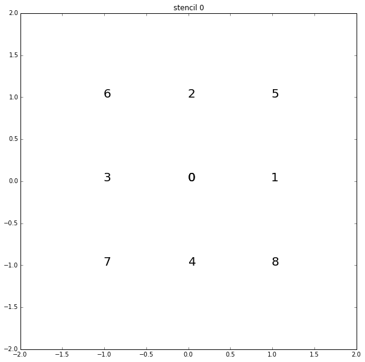

```python
v = pyLBM.viewer.MatplotlibViewer()
s.visualize(v)
```

### Stencil pour deux schémas à 4 vitesses et un schéma à 9 vitesses

```python
s = pyLBM.Stencil({'dim': 2,
                   'schemes': [{'velocities': range(1, 5)},
                               {'velocities': range(1, 5)},
                               {'velocities': range(9)},
                              ]
                  })

print s
```

```
Stencil informations
	 * spatial dimension: 2
	 * maximal velocity in each direction: [1 1 None]
	 * minimal velocity in each direction: [-1 -1 None]
	 * Informations for each elementary stencil:
		stencil 0
		 - number of velocities:  4
		 - velocities: (1: 1, 0), (2: 0, 1), (3: -1, 0), (4: 0, -1),
		stencil 1
		 - number of velocities:  4
		 - velocities: (1: 1, 0), (2: 0, 1), (3: -1, 0), (4: 0, -1),
		stencil 2
		 - number of velocities:  9
		 - velocities: (0: 0, 0), (1: 1, 0), (2: 0, 1), (3: -1, 0), (4: 0, -1), (5: 1, 1), (6: -1, 1), (7: -1, -1), (8: 1, -1),
```

```python
s.vmax
```

```
array([1, 1, None], dtype=object)
```

```python
s.uvx
```

```
array([ 0,  1,  0, -1,  0,  1, -1, -1,  1])
```

```python
s.vx[0]
```

```
array([ 1,  0, -1,  0])
```

```python
s.vx[2]
```

```
array([ 0,  1,  0, -1,  0,  1, -1, -1,  1])
```

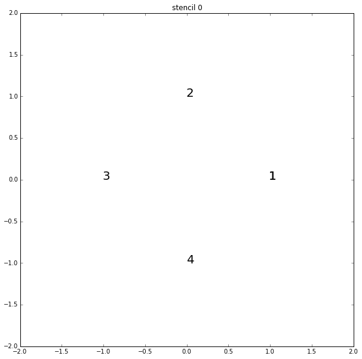

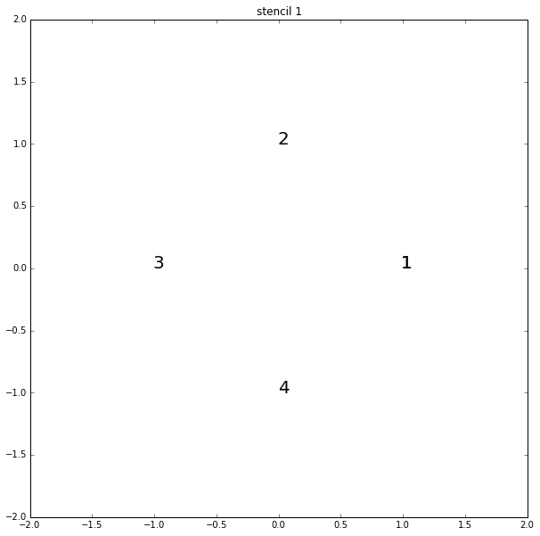

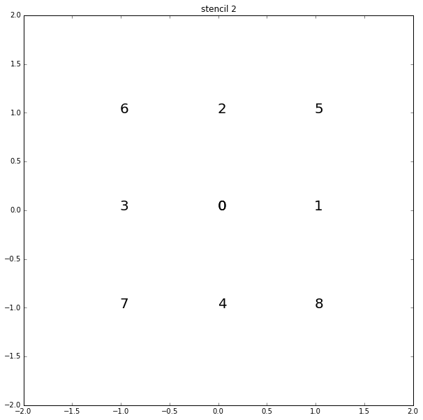

```python
s.visualize(v)
```

### Une géométrie

pyLBM gère des géométries 1D, 2D et 3D. Pour le moment, seule la dimension 2 gère les obstacles.

On initialise une géométrie en donnant les dimensions de la boite et les labels aux bords.

Pour la dimension 2, on peut ajouter les obstacles élémentaires suivants

- un cercle,
- un parallélogramme,
- un triangle.

### Boite 2D

```python
g = pyLBM.Geometry({'box': {'x': [0, 1], 'y': [0, 1], 'label':0},
                  })
print g
```

```
Geometry informations
	 spatial dimension: 2
	 bounds of the box:
[[ 0.  1.]
 [ 0.  1.]]
```

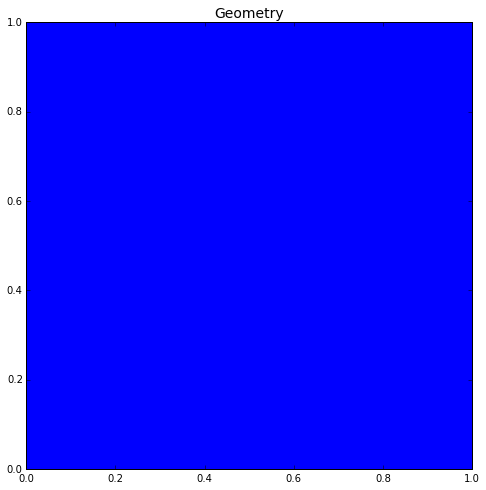

```python
g.visualize()
```

### Boite 2D avec obstacles

```python
square = pyLBM.Parallelogram((.1, .1), (.8, 0), (0, .8), isfluid=False)
strip = pyLBM.Parallelogram((0, .4), (1, 0), (0, .2), isfluid=True)
circle = pyLBM.Circle((.5, .5), .25, isfluid=True)
inner_square = pyLBM.Parallelogram((.4, .5), (.1, .1), (.1, -.1), isfluid=False)
g = pyLBM.Geometry({'box':{'x': [0, 1], 'y': [0, 1], 'label':0},
                    'elements':[square, strip, circle, inner_square],
                    })

print g
```

```
Geometry informations
	 spatial dimension: 2
	 bounds of the box:
[[ 0.  1.]
 [ 0.  1.]]
	 List of elements added or deleted in the box
		 Element number 0: Parallelogram([ 0.1  0.1],[ 0.8  0. ],[ 0.   0.8]) (solid)
		 Element number 1: Parallelogram([ 0.   0.4],[1 0],[ 0.   0.2]) (fluid)
		 Element number 2: Circle([ 0.5  0.5],0.25) (fluid)
		 Element number 3: Parallelogram([ 0.4  0.5],[ 0.1  0.1],[ 0.1 -0.1]) (solid)
```

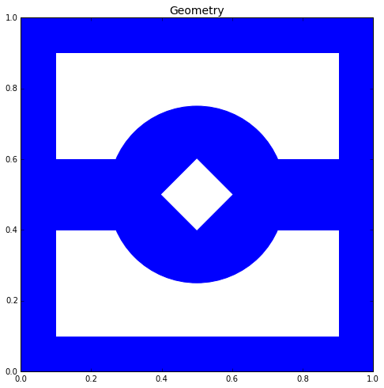

```python
g.visualize()
```

### Le domaine

Le domaine est représenté par une géométrie, un ou des schémas et un pas d'espace.

#### Fonctionalités

- indique quels points du maillage est fluide ou solide,
- calcule les distances pour chaque vitesse unique entre les points du maillage et le bord des obstacles,
- fournit les labels des bords appartenant à la distance minimale calculée.

### Domaine 2D vide

```python
s = pyLBM.Domain({'box': {'x': [0, 1], 'y': [0, 1], 'label':0},
                  'space_step': .1,
                  'schemes': [{'velocities': range(9)}]
                  })
print s
```

```
Domain informations
	 spatial dimension: 2
	 bounds of the box: bounds = [[ 0.  1.]
 [ 0.  1.]]
	 space step: dx= 1.000e-01
```

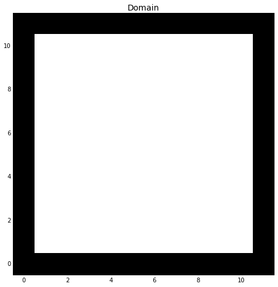

```python
s.visualize()
```

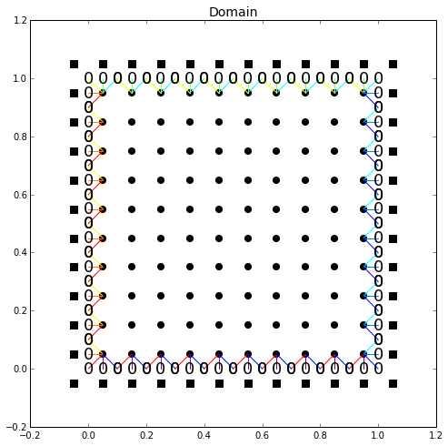

```python
s.visualize(1)
```

### Ajout d'obstacles

```python
d = pyLBM.Domain({'box': {'x': [0, 1], 'y': [0, 1], 'label':0},
                  'elements': [pyLBM.Circle((.25, .5), .2)],
                  'space_step': .05,
                  'schemes': [{'velocities': range(9)}]
                  })
```

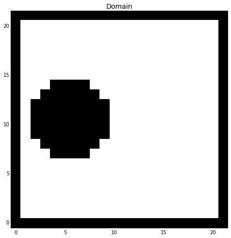

```python
d.visualize()
```

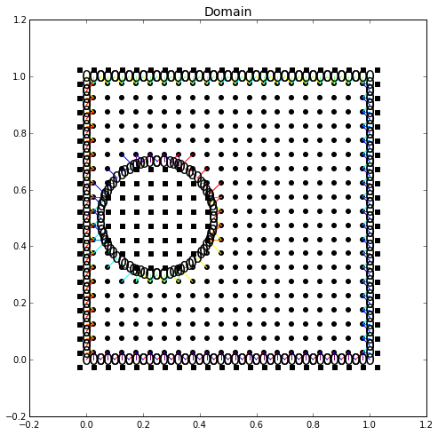

```python
d.visualize(1)
```

### Le schéma

Pour construire un schéma, il faut donner les informations suivantes

- les vitesses,
- les moments conservés,
- les polynômes,
- les équilibres,
- les termes de relaxations.

### Navier-Stokes $D_2Q_9$

```python
import sympy as sp

X, Y = sp.symbols('X, Y')
rho, qx, qy = sp.symbols('rho, qx, qy')

dx = 1./256    # space step
eta = 1.25e-5  # shear viscosity
kappa = 10*eta # bulk viscosity
sb = 1./(.5+kappa*3./dx)
ss = 1./(.5+eta*3./dx)
d = {
    'dim':2,
    'scheme_velocity':1.,
    'schemes':[{
        'velocities':range(9),
        'polynomials':[
            1, X, Y,
            3*(X**2+Y**2)-4,
            (9*(X**2+Y**2)**2-21*(X**2+Y**2)+8)/2,
            3*X*(X**2+Y**2)-5*X, 3*Y*(X**2+Y**2)-5*Y,
            X**2-Y**2, X*Y
        ],
        'relaxation_parameters':[0., 0., 0., sb, sb, sb, sb, ss, ss],
        'equilibrium':[
            rho, qx, qy,
            -2*rho + 3*qx**2 + 3*qy**2,
            rho + 3/2*qx**2 + 3/2*qy**2,
            -qx, -qy,
            qx**2 - qy**2, qx*qy
        ],
        'conserved_moments': [rho, qx, qy],
    },],
}
s = pyLBM.Scheme(d)
```

```
[0] WARNING  pyLBM.scheme in function set_initialization
You don't define initialization step for your conserved moments
WARNING:pyLBM.scheme:You don't define initialization step for your conserved moments
```

```python
print s
```

```
Scheme informations
	 spatial dimension: dim=2
	 number of schemes: nscheme=1
	 number of velocities:
    Stencil.nv[0]=9
	 velocities value:
    v[0]=(0: 0, 0), (1: 1, 0), (2: 0, 1), (3: -1, 0), (4: 0, -1), (5: 1, 1), (6: -1, 1), (7: -1, -1), (8: 1, -1),
	 polynomials:
    P[0]=Matrix([[1], [X], [Y], [3*X**2 + 3*Y**2 - 4], [-21*X**2/2 - 21*Y**2/2 + 9*(X**2 + Y**2)**2/2 + 4], [3*X*(X**2 + Y**2) - 5*X], [3*Y*(X**2 + Y**2) - 5*Y], [X**2 - Y**2], [X*Y]])
	 equilibria:
    EQ[0]=Matrix([[rho], [qx], [qy], [3*qx**2 + 3*qy**2 - 2*rho], [qx**2 + qy**2 + rho], [-qx], [-qy], [qx**2 - qy**2], [qx*qy]])
	 relaxation parameters:
    s[0]=[0.0, 0.0, 0.0, 1.6778523489932886, 1.6778523489932886, 1.6778523489932886, 1.6778523489932886, 1.9623233908948192, 1.9623233908948192]
	 moments matrices
M = [Matrix([
[ 1,  1,  1,  1,  1, 1,  1,  1,  1],
[ 0,  1,  0, -1,  0, 1, -1, -1,  1],
[ 0,  0,  1,  0, -1, 1,  1, -1, -1],
[-4, -1, -1, -1, -1, 2,  2,  2,  2],
[ 4, -2, -2, -2, -2, 1,  1,  1,  1],
[ 0, -2,  0,  2,  0, 1, -1, -1,  1],
[ 0,  0, -2,  0,  2, 1,  1, -1, -1],
[ 0,  1, -1,  1, -1, 0,  0,  0,  0],
[ 0,  0,  0,  0,  0, 1, -1,  1, -1]])]
invM = [Matrix([
[1/9,    0,    0,  -1/9,   1/9,     0,     0,    0,    0],
[1/9,  1/6,    0, -1/36, -1/18,  -1/6,     0,  1/4,    0],
[1/9,    0,  1/6, -1/36, -1/18,     0,  -1/6, -1/4,    0],
[1/9, -1/6,    0, -1/36, -1/18,   1/6,     0,  1/4,    0],
[1/9,    0, -1/6, -1/36, -1/18,     0,   1/6, -1/4,    0],
[1/9,  1/6,  1/6,  1/18,  1/36,  1/12,  1/12,    0,  1/4],
[1/9, -1/6,  1/6,  1/18,  1/36, -1/12,  1/12,    0, -1/4],
[1/9, -1/6, -1/6,  1/18,  1/36, -1/12, -1/12,    0,  1/4],
[1/9,  1/6, -1/6,  1/18,  1/36,  1/12, -1/12,    0, -1/4]])]
```

### Les conditions de bords

- périodique,
- bounce-back et anti bounce-back,
- Neumann,
- Bouzidi.

### Hiérarchie des différents blocs

[figure not shown]

### Génération automatique

Une fois les paramètres de l'utilisateur analysés, on génère automatiquement

- le passage entre les fonctions de distributions et les moments,
- l'équilibre,
- le transport,
- la relaxation.

#### Versions disponibles

- NumPy
- Cython
- Pythran
- Numba

### Version Numpy

Les fonctions générées sont écrites de manière vectorielle et indépendante. Un pas de temps s'écrit

- *transport*
- *f2m*
- *relaxation*
- *m2f*

### Les autres versions

On implémente l'algorithme *pull*

[figure not shown]

Un pas de temps s'écrit

- on lit les données dans l'ancien f (phase de transport)
- f2m
- relaxation
- m2f
- on stocke les données dans le nouveau f

## Cavité entrainée 2D

[figure not shown]

### L'initialisation

```python
def bc_up(f, m, x, y, scheme):
    m[:, 0] = 0.
    m[:, 1] = driven_velocity
    m[:, 2] = 0.
    scheme.equilibrium(m)
    scheme.m2f(m, f)

mu   = 1.e-4
zeta = 1.e-4
driven_velocity = 0.2 # velocity of the upper border
dx = 1./256
dummy = 3.0/dx
s1 = 1.0/(0.5+zeta*dummy)
s2 = 1.0/(0.5+mu*dummy)
s  = [0.,0.,0.,s1,s1,s1,s1,s2,s2]
```

### Le schéma

```python
lid_cavity = {'box':{'x':[0., 1.], 'y':[0., 1.], 'label':[0, 0, 1, 0]},
              'space_step': dx,
              'scheme_velocity':1,
              'schemes':[{'velocities':range(9),
                          'polynomials':[1,
                                   X, Y,
                                   3*(X**2+Y**2)-4,
                                   0.5*(9*(X**2+Y**2)**2-21*(X**2+Y**2)+8),
                                   3*X*(X**2+Y**2)-5*X, 3*Y*(X**2+Y**2)-5*Y,
                                   X**2-Y**2, X*Y],
                          'relaxation_parameters':s,
                          'equilibrium':[rho, qx, qy,
                                        -2*rho + 3*qx**2 + 3*qy**2,
                                        rho + 3/2*qx**2 + 3/2*qy**2,
                                        -qx, -qy,
                                        qx**2 - qy**2, qx*qy],
                          'conserved_moments': [rho, qx, qy],
                          'init': {rho: 1., qx: 0., qy: 0.},
              }],
              'boundary_conditions':{
                 0:{'method':{0: pyLBM.bc.bouzidi_bounce_back}, 'value':None},
                 1:{'method':{0: pyLBM.bc.bouzidi_bounce_back}, 'value':bc_up}
              },
              'generator': pyLBM.CythonGenerator,
              }
```

### La simulation

```python
sol = pyLBM.Simulation(lid_cavity)
```

```python
Tf = 40.
while (sol.t<Tf):
    sol.one_time_step()
```

[video not shown]

## Allées de Von Karman

[figure not shown]

### L'initialisation

```python
def bc_rect(f, m, x, y, scheme):
    m[:, 0] = 0.
    m[:, 1] = uo
    m[:, 2] = 0.
    scheme.equilibrium(m)
    scheme.m2f(m, f)

uo = 0.05
mu   = 2.5e-5
zeta = 10*mu
dx = 1./256
dummy = 3.0/dx
s1 = 1.0/(0.5+zeta*dummy)
s2 = 1.0/(0.5+mu*dummy)
s  = [0.,0.,0.,s1,s1,s1,s1,s2,s2]
```

### Le schéma

```python
karman = {'box':{'x':[0., 2.], 'y':[0., 1.], 'label':[0, 1, 0, 0]},
          'elements':[pyLBM.Circle([.3, 0.3], .05, label=2),
                      pyLBM.Circle([.2, 0.5], .05, label=2),
                      pyLBM.Circle([.3, 0.7], .05, label=2)],
          'space_step': dx,
          'scheme_velocity':1,
          'schemes':[{'velocities':range(9),
                      'polynomials':[1,
                                   X, Y,
                                   3*(X**2+Y**2)-4,
                                   0.5*(9*(X**2+Y**2)**2-21*(X**2+Y**2)+8),
                                   3*X*(X**2+Y**2)-5*X, 3*Y*(X**2+Y**2)-5*Y,
                                   X**2-Y**2, X*Y],
                      'relaxation_parameters':s,
                      'equilibrium':[rho, qx, qy,
                                     -2*rho + 3*qx**2 + 3*qy**2,
                                     rho + 3/2*qx**2 + 3/2*qy**2,
                                     -qx, -qy,
                                     qx**2 - qy**2, qx*qy],
                      'conserved_moments': [rho, qx, qy],
                      'init': {rho: 1., qx: uo, qy: 0.},
          }],
          'boundary_conditions':{
               0:{'method':{0: pyLBM.bc.bouzidi_bounce_back}, 'value':bc_rect},
               1:{'method':{0: pyLBM.bc.neumann_vertical}, 'value':None},
               2:{'method':{0: pyLBM.bc.bouzidi_bounce_back}, 'value':None},
          },
          'generator': pyLBM.CythonGenerator,
          }
```

### La simulation

```python
sol = pyLBM.Simulation(karman)
```

```python
Tf = 20.
while (sol.t<Tf):
    sol.one_time_step()
```

[video not shown]

## Shallow water

[figure not shown]

### L'initialisation

```python
dx = 1./512 # spatial step
la = 4 # velocity of the scheme
rhoo = 1.
deltarho = 1.
g = 1.

X, Y, LA = sp.symbols('X,Y,LA')
rho, qx, qy = sp.symbols('rho, qx, qy')

def initialization_rho(x,y):
    return rhoo * np.ones((x.size, y.size)) + deltarho * ((x**2 + y**2) < 0.25**2)

vitesse = range(1,5)
polynomes = [1, LA*X, LA*Y, X**2-Y**2]
```

### Le schéma

```python
shallow   = {
    'box':{'x':[-.5, .5], 'y':[-.5, .5], 'label':-1},
    'space_step':dx,
    'scheme_velocity':la,
    'schemes':[{'velocities':vitesse,
                'polynomials':polynomes,
                'relaxation_parameters':[0., 2., 2., 1.5],
                'equilibrium':[rho, qx, qy, 0.],
                'conserved_moments': rho,
                'init':{rho:(initialization_rho,)},
                },
                {'velocities':vitesse,
                'polynomials':polynomes,
                'relaxation_parameters':[0., 1.5, 1.5, 1.2],
                'equilibrium': [qx, qx**2/rho + 0.5*g*rho**2, qx*qy/rho, 0.],
                'conserved_moments': qx,
                'init':{qx: 0.},
                },
                {'velocities':vitesse,
                'polynomials':polynomes,
                'relaxation_parameters':[0., 1.5, 1.5, 1.2],
                'equilibrium': [qy, qx*qy/rho, qy**2/rho + 0.5*g*rho**2, 0.],
                'conserved_moments': qy,
                'init':{qy: 0.},
                },
    ],
    'parameters': {LA: la},
    'generator': pyLBM.CythonGenerator,
    }
```

### La simulation

```python
sol = pyLBM.Simulation(shallow)
```

```python
Tf = 2.
while (sol.t<Tf):
    sol.one_time_step()
```

[video not shown]

#### Améliorations futures

- les conditions de bords
- les obstacles en 3D
- analyse des performances
- GPU

#### Réflexions

- stockage et phase de transport
- raffinement automatique
- multiphasique
- surface libre
- ...

## Questions ?

[figure not shown]